# Linear Regression (Bike Sharing Demand)

Mela Feriani Simanjuntak

1/9/2022

## The Data

I get the Data from [Bike Sharing Demand Kaggle challenge!](https://www.kaggle.com/c/bike-sharing-demand/overview)

The data has the following features:

- Datetime - hourly date + timestamp
- season - 1 = spring, 2 = summer, 3 = fall, 4 = winter
- holiday - whether the day is considered a holiday
- workingday - whether the day is neither a weekend nor holiday
- weather -
  - 1: Clear, Few clouds, Partly cloudy, Partly cloudy
  - 2: Mist + Cloudy, Mist + Broken clouds, Mist + Few clouds, Mist
  - 3: Light Snow, Light Rain + Thunderstorm + Scattered clouds, Light Rain + Scattered clouds
  - 4: Heavy Rain + Ice Pallets + Thunderstorm + Mist, Snow + Fog
- temp - temperature in Celsius
- atemp - “feels like” temperature in Celsius
- humidity - relative humidity
- windspeed - wind speed
- casual - number of non-registered user rentals initiated
- registered - number of registered user rentals initiated
- count - number of total rentals

```r
bike <- read.csv('bikeshare.csv')
```

```r
head(bike)
```

```
##              datetime season holiday workingday weather temp  atemp humidity
## 1 2011-01-01 00:00:00      1       0          0       1 9.84 14.395       81
## 2 2011-01-01 01:00:00      1       0          0       1 9.02 13.635       80
## 3 2011-01-01 02:00:00      1       0          0       1 9.02 13.635       80
## 4 2011-01-01 03:00:00      1       0          0       1 9.84 14.395       75
## 5 2011-01-01 04:00:00      1       0          0       1 9.84 14.395       75
## 6 2011-01-01 05:00:00      1       0          0       2 9.84 12.880       75
##   windspeed casual registered count
## 1    0.0000      3         13    16
## 2    0.0000      8         32    40
## 3    0.0000      5         27    32
## 4    0.0000      3         10    13
## 5    0.0000      0          1     1
## 6    6.0032      0          1     1
```

##### From the data, we know we are trying to predict *count*

## Exploratory Data Analysis

#### We create a scatter plot of count vs temp. and set a good alpha value.

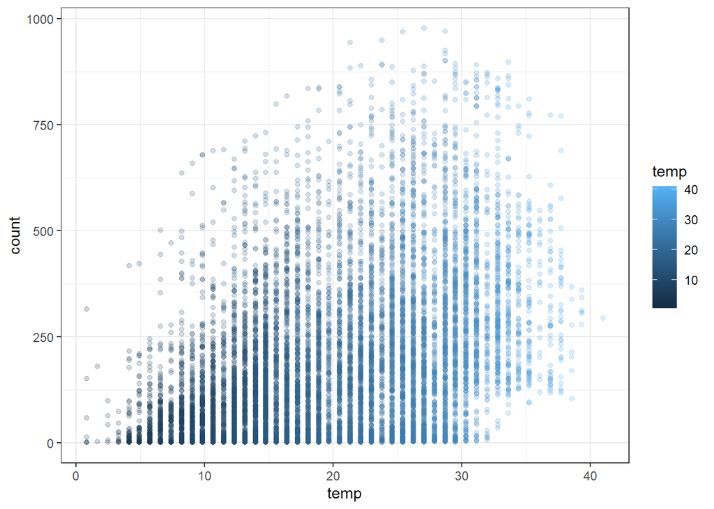

```r
library(ggplot2)
ggplot(bike,aes(temp,count)) + geom_point(alpha=0.2, aes(color=temp)) + theme_bw()
```

**Plot count versus datetime as a scatterplot with a color gradient based on temperature. We have to convert the datetime column into POSIXct before plotting**.

```r
bike$datetime <- as.POSIXct(bike$datetime)
```

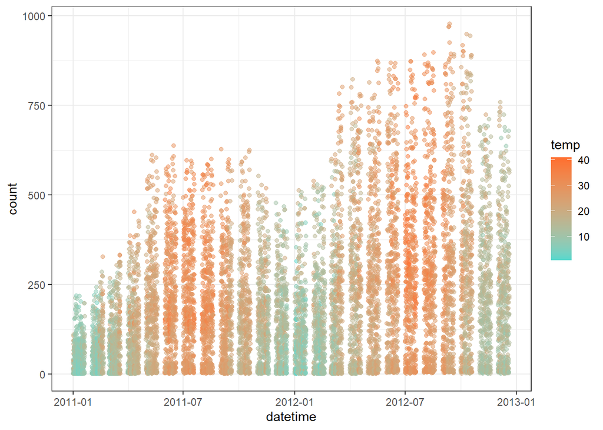

```r
ggplot(bike,aes(datetime,count)) + geom_point(aes(color=temp),alpha=0.5)  + scale_color_continuous(low='#55D8CE',high='#FF6E2E') +theme_bw()
```

**We noticed two things: A seasonality to the data, for winter and summer. Also that bike rental counts are increasing in general. This may present a problem with using a linear regression model if the data is non-linear.**

Let’s have a quick overview of pros and cons right now of Linear Regression:

Pros:

- Simple to explain
- Highly interpretable
- Model training and prediction are fast
- No tuning is required (excluding regularization)
- Features don’t need scaling
- Can perform well with a small number of observations
- Well-understood

Cons:

- Assumes a linear relationship between the features and the response
- Performance is (generally) not competitive with the best supervised learning methods due to high bias
- Can’t automatically learn feature interactions

#### What is the correlation between temp and count?

```r
cor(bike[,c('temp','count')])
```

```
##            temp     count
## temp  1.0000000 0.3944536
## count 0.3944536 1.0000000
```

**Let’s explore the season data. We will create a boxplot, with the y axis indicating count and the x axis begin a box for each season.**

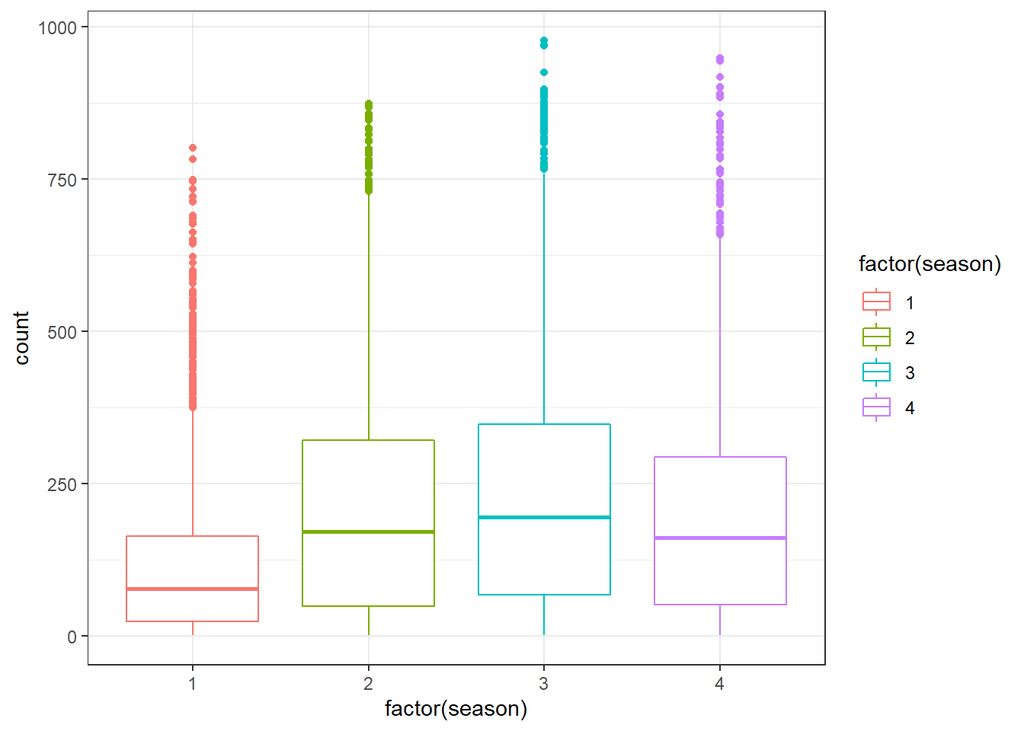

```r
ggplot(bike,aes(factor(season),count)) + geom_boxplot(aes(color=factor(season))) +theme_bw()
```

**This says:**

- A line can’t capture a non-linear relationship.
- There are more rentals in winter than in spring.

**We know of these issues because of the growth of rental count, this isn’t due to the actual season**

## Feature Engineering

Let’s go ahead and engineer some new features from the datetime column.

We will create an “hour” column that takes the hour from the datetime column. We need to apply some function to the entire datetime column and reassign it.

```r
bike$hour <- sapply(bike$datetime,function(x){format(x,"%H")})
```

```r
head(bike)
```

```
##              datetime season holiday workingday weather temp  atemp humidity
## 1 2011-01-01 00:00:00      1       0          0       1 9.84 14.395       81
## 2 2011-01-01 01:00:00      1       0          0       1 9.02 13.635       80
## 3 2011-01-01 02:00:00      1       0          0       1 9.02 13.635       80
## 4 2011-01-01 03:00:00      1       0          0       1 9.84 14.395       75
## 5 2011-01-01 04:00:00      1       0          0       1 9.84 14.395       75
## 6 2011-01-01 05:00:00      1       0          0       2 9.84 12.880       75
##   windspeed casual registered count hour
## 1    0.0000      3         13    16   00
## 2    0.0000      8         32    40   01
## 3    0.0000      5         27    32   02
## 4    0.0000      3         10    13   03
## 5    0.0000      0          1     1   04
## 6    6.0032      0          1     1   05
```

**Now we will create a scatterplot of count versus hour, with color scale based on temp. We only use bike data where workingday==1.**

**Optional Additions:**

- We use the additional layer: scale_color_gradientn(colors=c(‘color1’,color2,etc..)) where the colors argument is a vector gradient of colors you choose, not just high and low.
- We use position=position_jitter(w=1, h=0) inside of geom_point() and check out what it does.

```r
library(dplyr)
```

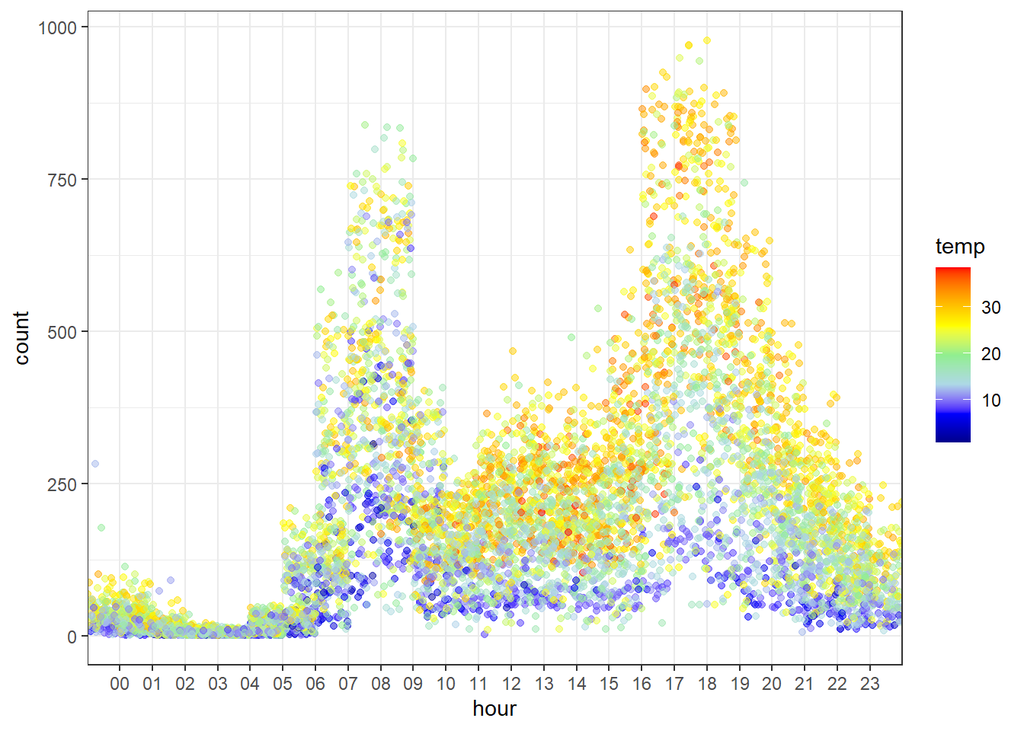

```r
pl <- ggplot(filter(bike,workingday==1),aes(hour,count))
pl <- pl + geom_point(position=position_jitter(w=1, h=0),aes(color=temp),alpha=0.5)
pl <- pl + scale_color_gradientn(colours = c('dark blue','blue','light blue','light green','yellow','orange','red'))
pl + theme_bw()
```

**Now we create the same plot for non working days:**

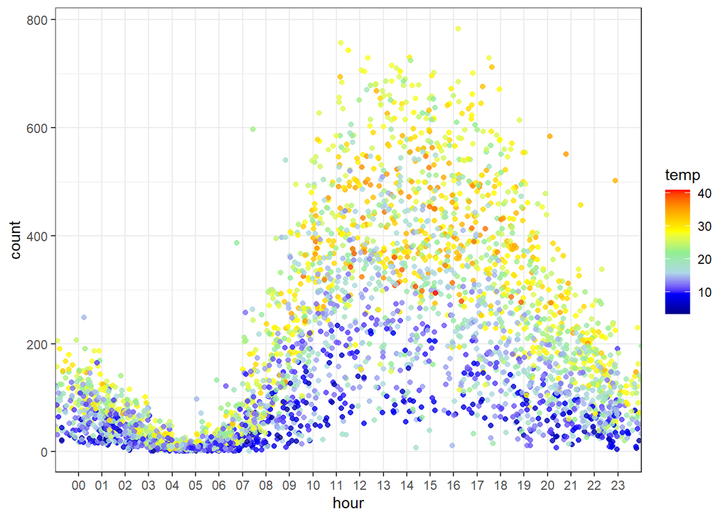

```r
pl <- ggplot(filter(bike,workingday==0),aes(hour,count))
pl <- pl + geom_point(position=position_jitter(w=1, h=0),aes(color=temp),alpha=0.8)
pl <- pl + scale_color_gradientn(colours = c('dark blue','blue','light blue','light green','yellow','orange','red'))
pl + theme_bw()
```

**We should have noticed that working days have peak activity during the morning (~8am) and right after work gets out (~5pm), with some lunchtime activity. While the non-work days have a steady rise and fall for the afternoon**

**Now let’s continue by trying to build a model, we’ll begin by just looking at a single feature.**

## Building the Model

**We will use lm() to build a model that predicts count based solely on the temp feature, we name it temp.model**

```r
temp.model <- lm(count~temp,bike)
```

```r
summary(temp.model)
```

```
##
## Call:
## lm(formula = count ~ temp, data = bike)
##
## Residuals:
##     Min      1Q  Median      3Q     Max
## -293.32 -112.36  -33.36   78.98  741.44
##
## Coefficients:
##             Estimate Std. Error t value Pr(>|t|)
## (Intercept)   6.0462     4.4394   1.362    0.173
## temp          9.1705     0.2048  44.783   <2e-16 ***
## ---
## Signif. codes:  0 '***' 0.001 '**' 0.01 '*' 0.05 '.' 0.1 ' ' 1
##
## Residual standard error: 166.5 on 10884 degrees of freedom
## Multiple R-squared:  0.1556, Adjusted R-squared:  0.1555
## F-statistic:  2006 on 1 and 10884 DF,  p-value: < 2.2e-16
```

### Interpreting the intercept (β0):

- It is the value of y when x=0.
- Thus, it is the estimated number of rentals when the temperature is 0 degrees Celsius.
- Note: It does not always make sense to interpret the intercept.

## Interpreting the “temp” coefficient (β1):

- It is the change in y divided by change in x, or the “slope”.
- Thus, a temperature increase of 1 degree Celsius is associated with a rental increase of 9.17 bikes.
- This is not a statement of causation.
- β1 would be negative if an increase in temperature was associated with a decrease in rentals.

**How many bike rentals would we predict if the temperature was 25 degrees Celsius? We will calculate this two ways:**

- Using the values we just got above
- Using the predict() function

We should get around 235.3 bikes.

```r
# Method 1
6.0462 + 9.17*25
```

```
## [1] 235.2962
```

```r
# Method 2
temp.test <- data.frame(temp=c(25))
predict(temp.model,temp.test)
```

```
##        1
## 235.3097
```

**Lets use sapply() and as.numeric to change the hour column to a column of numeric values.**

```r
bike$hour <- sapply(bike$hour,as.numeric)
```

```r
model <- lm(count ~ . -casual - registered -datetime -atemp,bike )
```

**Summary of the model**

```r
summary(model)
```

```
##
## Call:
## lm(formula = count ~ . - casual - registered - datetime - atemp,
##     data = bike)
##
## Residuals:
##     Min      1Q  Median      3Q     Max
## -324.61  -96.88  -31.01   55.27  688.83
##
## Coefficients:
##              Estimate Std. Error t value Pr(>|t|)
## (Intercept)  46.91369    8.45147   5.551 2.91e-08 ***
## season       21.70333    1.35409  16.028  < 2e-16 ***
## holiday     -10.29914    8.79069  -1.172    0.241
## workingday   -0.71781    3.14463  -0.228    0.819
## weather      -3.20909    2.49731  -1.285    0.199
## temp          7.01953    0.19135  36.684  < 2e-16 ***
## humidity     -2.21174    0.09083 -24.349  < 2e-16 ***
## windspeed     0.20271    0.18639   1.088    0.277
## hour          7.61283    0.21688  35.102  < 2e-16 ***
## ---
## Signif. codes:  0 '***' 0.001 '**' 0.01 '*' 0.05 '.' 0.1 ' ' 1
##
## Residual standard error: 147.8 on 10877 degrees of freedom
## Multiple R-squared:  0.3344, Adjusted R-squared:  0.3339
## F-statistic:   683 on 8 and 10877 DF,  p-value: < 2.2e-16
```

**Did the model perform well on the training data?**

A linear model like the one we chose which uses OLS won’t be able to take into account seasonality of our data, and will get thrown off by the growth in our dataset, accidentally attributing it towards the winter season, instead of realizing its just overall demand growing! Later on, we’ll see if other models may be a better fit for this sort of data.

**We should have noticed that this sort of model doesn’t work well given our seasonal and time series data. We need a model that can account for this type of trend.**